# PTM First Pass

Erik VonKaenel

2024-07-16

Packages

```r
library(OrgMassSpecR)
library(tidyverse)
library(pmartR)

here::i_am("Code/ptm_simulation_and_dials.Rmd")

source(here::here("Code", "protein_quant2.R"))

seed = 1
```

Helper Functions

```r
add_char_at_n = function(original_string, new_char, n) {
  # Split the string into two parts
  part1 = substr(original_string, 1, n - 1)
  part2 = substr(original_string, n, nchar(original_string))

  # Concatenate the parts with the new character
  modified_string = paste0(part1, new_char, part2)

  return(modified_string)
}

generate_random_protein = function(n) {
  amino_acids = c("A", "R", "N", "D", "C", "E", "Q", "G", "H", "I",
                   "L", "K", "M", "F", "P", "S", "T", "W", "Y", "V")
  random_sequence = sample(amino_acids, size = n, replace = TRUE)
  random_sequence_string = paste(random_sequence, collapse = "")
  return(random_sequence_string)
}

add_ptms = function(sequence, amino_acid, identifier) {
  modified_string = str_replace_all(sequence, amino_acid, paste0(amino_acid, identifier))
  return(modified_string)
}

get_ptm_locations = function(sequence, amino_acid){
  return(stringr::str_locate_all(sequence, amino_acid)[[1]][,1])
}

get_ptm_site_mapping = function(sequence, amino_acid, drop_na = TRUE){
  digest_results = Digest(sequence)
  ptm_locations = get_ptm_locations(sequence, amino_acid)
  tmp_df = c()
  for(i in seq_along(ptm_locations)){
    peptide_id = which(ptm_locations[i] >= digest_results$start & ptm_locations[i] <= digest_results$stop)
    tmp_df = rbind(tmp_df, c(peptide = digest_results$peptide[peptide_id], site = paste0("@", amino_acid, ptm_locations[i])))
  }
  out = digest_results %>% left_join(., as_tibble(tmp_df), by = 'peptide') %>% mutate(protein = sequence)  %>% select(site, peptide, protein, start, stop)
  if(drop_na) out = out %>% filter(!is.na(site))
  return(out)
}

get_modify_indices = function(e_meta, sequence_abundance){
  unique_sites = unique(e_meta$site)
  num_sites = length(unique_sites)
  ptm_abundances = sample(seq_len(sequence_abundance), num_sites)
  modify_indices = sapply(ptm_abundances, \(x) seq_len(sequence_abundance) %in% sample(seq_len(sequence_abundance), x))
  colnames(modify_indices) = unique_sites
  return(modify_indices)
}

ptm_at_site = function(peptide, site, identifier, start){
  location = as.numeric(substr(site, 3, nchar(site))) - start + 2
  return(add_char_at_n(peptide, identifier, location))
}

ptm_at_sites = function(peptide, sites, identifier, start){
  for(site in sites){
    peptide = ptm_at_site(peptide, site, identifier = identifier, start = start)
    start = start - 1
  }
  return(peptide)
}

modify_and_count = function(e_meta, modify_indices){
  peps = unique(e_meta$peptide)
  out_dat = c()
  for(i in seq_along(peps)){
    pep_e_meta = e_meta %>% filter(peptide == peps[i])
    tmp_site = pep_e_meta %>% pull(site)
    site_modifications = matrix(modify_indices[,colnames(modify_indices) %in% tmp_site], ncol = length(tmp_site))
    colnames(site_modifications) = tmp_site
    site_modification_counts = table(apply(site_modifications, 1, \(x) paste0(colnames(site_modifications)[x], collapse = ";")))
    #drop no modification case here
    site_modification_counts = site_modification_counts[names(site_modification_counts) != '']

    for(j in seq_along(site_modification_counts)){
      curr_ptm = site_modification_counts[j]
      sites = strsplit(names(curr_ptm), split = ';')[[1]]
      ptm = ptm_at_sites(peps[i], sites, "#", pep_e_meta %>% filter(site %in% sites) %>% pull(start) %>% unique)
      out_dat = rbind(out_dat, tibble(peptide = ptm, site = sites, peptide_count = curr_ptm))
    }
  }
  return(out_dat)
}

generate_ptm_samples_for_sequence = function(ptm_site_mapping,
                                             sequence_abundances,
                                             subject_coefs,
                                             site_coefs,
                                             group_ids){
  #assert length(sequence_abundances) = length(subject_coef)

  e_data_full = c()
  e_meta_full = c()
  ground_truth = c()
  for(j in seq_along(sequence_abundances)){
    modify_indices = get_modify_indices(ptm_site_mapping, sequence_abundances[j]) #sequence should depend on group
    ground_truth = cbind(ground_truth, colSums(modify_indices))

    for(i in seq_len(sum(group_ids == 1))){
      e_data = modify_and_count(ptm_site_mapping, modify_indices)
      e_meta = e_data %>% rename(true_peptide_count = peptide_count)

      e_data_subj = e_data %>% mutate(peptide_count = peptide_count * exp(subject_coefs[i]))
      names(e_data_subj)[3] = paste0("Subject_", i, "_G", j)

      if(i == 1 & j == 1){
        e_data_full = e_data_subj
      } else {
        e_data_full = e_data_full %>%
          full_join(e_data_subj, by = c("peptide", "site")) %>%
          mutate_if(is.numeric,coalesce, 0)
      }

      if(i == 1) e_meta_full = rbind(e_meta_full, e_meta %>% mutate(group = j))
    }
  }

  coef_dat = tibble(Mult_Factor = exp(site_coefs), site = unique(e_meta_full$site))
  e_data_full = e_data_full %>%
    left_join(., coef_dat) %>%
    select(-site) %>%
    group_by(peptide) %>%
    summarise(Mult_Factor = prod(Mult_Factor),
              across(starts_with("Subject"), ~ mean(.x))) %>%
    mutate(across(starts_with("Subject"), ~ . * Mult_Factor)) %>%
    select(-Mult_Factor)

  return(list(e_data = e_data_full, e_meta = e_meta_full, ground_truth = ground_truth))
}
```

# Simulated PTM Data

Consider an protein as an amino acid sequence of length $Q$, which is modified at $R \leq Q$ distinct locations, or sites, in the sequence. Let $M$ be the absolute abundance of the sequence. For each site $r \in \{1, ..., R\}$, we uniformly sample $m_r <= M$ of the $M$ total sequences without replacement to modify at site $r$. Currently,
$$m_r \sim U(1, M)$$
, where $U()$ denoted the uniform distribution, which is interpreted at the true abundance at site $r$. This can be operationalized as an $M \times R$ binary matrix $A$, where $A_{m, r} = 1$ indicates protein $m$ was modified at site $r$, and $A_{m, r} = 0$ indicates protein $m$ was not modified at site $r$. Modified proteins are then artificially digested into modified peptides, and the true modified peptide abundance is taken as the count of each unique modified peptide.

Now denote the abundance of a peptide as $p$, and the set of modification sites for that peptide as $S \subset {1, ..., R}$. Then the modified peptide abundance is denoted by $p_{S}$. Additionally, consider $k = 1, ..., K$ groups, each with $N_k$ subjects. Site abundances $m_r$ are sampled separately for each group, denoted $m_{rk}$. We add site and subject effects to each peptide abundance as follows:
$$\tilde{p}_{i, k, S} = p_{S} * \exp[\beta_{ik}] *
\prod_{r \in S}\exp[\alpha_r]$$
where $i$ denotes the subject. This results in a linear modification of the log2 abundances:
$$\log_2 \tilde{p}_{i, k, S} = \log_2p_{S} +
\beta_{ik} + \sum_{\mathcal{r \in S}} \alpha_r$$
The subject effect acts as a random subject effect in a standard random effects model and is sampled via
$$\beta_{ik} \sim
N(0, \sigma_{subj})$$
and the site effect represents a modification of the abundance as a change in m/z from modification at site $r$, which is sampled via
$$\alpha_r \sim N(0, \sigma_{site})$$
.

Now the expected $\log_2$ modified peptide abundance $p_{S}$ for subject $i$ in group $k$ is
$$\begin{aligned}
E\big[ \log_2 \tilde{p}_{i, k_1, S} \big] &= E\big[ \log_2p_{S} +
\beta_{ik} + \Sigma_{\mathcal{r \in S}} \alpha_r \big] \\
& = E\big[ \log_2p_{S} \big] + E\big[ \beta_{ik} \big] +
\sum_{\mathcal{r \in S}}E\big[ \alpha_r \big] \\
&= \log_2 p_{S}
\end{aligned}$$

Then the expected $\log_2$ fold change comparing groups $k_1$ and $k_2$ is given as:

$$\begin{aligned}
E\big[\Sigma_i \log_2 \tilde{p}_{i, k_1, S} - \Sigma_i \log_2
\tilde{p}_{i, k_2, S} \big] &= \sum_{i = 1}^{n_{k_1}} E\big[ \log_2
\tilde{p}_{i, k_1, S} \big] - \sum_{i = 1}^{n_{k_2}} E\big[ \log_2
\tilde{p}_{i, k_2, S} \big] \\
&= \sum_{i = 1}^{n_{k_1}} \log_2 \tilde{p}_{i, k_1, S} - \sum_{i =
1}^{n_{k_2}} \log_2 \tilde{p}_{i, k_2, S} \\
&= \log_2 \bigg[ \frac{\prod_{i = 1}^{n_{k_1}} \tilde{p}_{i, k_1,
S}}{\prod_{i = 1}^{n_{k_2}} \tilde{p}_{i, k_2, S}} \bigg]
\end{aligned}$$

i.e. the true $\log_2$ fold change.

In this markdown, we will simulate data from one protein according to the above criteria, then evaluate the performance of rollup methods when the target is site-level data, rather than protein level data.

# Rollup Methods

Peptide rollup generally consists of two steps: scaling and aggregation. First, all abundances for peptides that map to the same entity are scaled according to some rule, then the rescaled abundances are into a single value according to some function. Below we discuss common scaling and aggregation methods.

Scaling Methods  
- rollup: No scaling is performed prior to aggregation.  
- rrollup: Abundances are scaled according to a chosen reference peptide, which is the peptide with the most observations.  
- zrollup: Abundances are first centered based on the median across all peptides that map to the entity, then scaled according to the sample standard devation.

Aggregation Methods  
- Sum  
- Mean  
- Median

# Toy Example

Start by using a random sequence

```r
set.seed(25)
sequence = generate_random_protein(300)
print(sequence)
```

```
## [1] "QTGHSDAGNHKLPRLSSHCNCDMDGNKFTKHWSFKGHRHYKKQYGGKTYLYWWWCNGWYI…"
```

We will target a modification on serine (S). Trypsin digestion is simulated without error.

```r
# set.seed(25)
amino_acid = "S"
identifier = "@"
```

## Simulation setup:

Set simulation values:

```r
set.seed(seed)
sequence_abundances = c(1000, 1000)

ptm_site_mapping = get_ptm_site_mapping(sequence, amino_acid)
site_sd = 0.1
site_coefs = rnorm(length(unique(ptm_site_mapping$site)), sd = site_sd)

n_per_group = 10
subject_effect_sd = 0.1
subject_coefs = rnorm(n_per_group * 2, sd = subject_effect_sd)
```

Simulate data:

```r
set.seed(seed)
out = generate_ptm_samples_for_sequence(ptm_site_mapping,
                                        sequence_abundances,
                                        subject_coefs,
                                        site_coefs,
                                        group_ids = rep(c(1, 2), each = n_per_group))

ground_truth = data.frame(site = rownames(out$ground_truth),
                          G1 = out$ground_truth[,1],
                          G2 = out$ground_truth[,2]) %>%
  mutate(true_fold_change = log2(G1 / G2)) %>%
  select(site, true_fold_change)

f_data_full = data.frame(sample = out$e_data %>% select(-peptide) %>% names,
                         group = rep(c(1, 2), each = n_per_group))
```

```r
pepdat = as.pepData(e_data = out$e_data,
                    f_data = f_data_full,
                    e_meta = out$e_meta %>% select(-group, -true_peptide_count) %>% distinct(),
                    edata_cname = "peptide",
                    fdata_cname = "sample",
                    emeta_cname = "site")
head(pepdat$e_data, 10) %>% knitr::kable()
```

| peptide | Subject_1_G1 | Subject_2_G1 | Subject_3_G1 | Subject_4_G1 | Subject_5_G1 | Subject_6_G1 | Subject_7_G1 | Subject_8_G1 | Subject_9_G1 | Subject_10_G1 | Subject_1_G2 | Subject_2_G2 | Subject_3_G2 | Subject_4_G2 | Subject_5_G2 | Subject_6_G2 | Subject_7_G2 | Subject_8_G2 | Subject_9_G2 | Subject_10_G2 |
| --- | --- | --- | --- | --- | --- | --- | --- | --- | --- | --- | --- | --- | --- | --- | --- | --- | --- | --- | --- | --- |
| AFQPHS#EDMVGQGPVHR | 433.196844 | 476.846615 | 471.035459 | 460.448672 | 475.662702 | 469.198015 | 437.14623 | 355.624744 | 461.643907 | 431.47017 | 182.10823 | 200.45781 | 198.01491 | 193.56441 | 199.96012 | 197.24248 | 183.76848 | 149.49830 | 194.06687 | 181.38237 |
| GHTS#GLYFPHEPGS#YPHCR | 186.685794 | 205.496624 | 202.992311 | 198.429945 | 204.986417 | 202.200467 | 188.38778 | 153.256167 | 198.945031 | 185.94169 | 531.33649 | 584.87501 | 577.74735 | 564.76215 | 583.42288 | 575.49364 | 536.18060 | 436.19063 | 566.22816 | 529.21865 |
| GHTS#GLYFPHEPGSYPHCR | 841.813333 | 926.636109 | 915.343533 | 894.770672 | 924.335460 | 911.772905 | 849.48800 | 691.070712 | 897.093323 | 838.45796 | 89.89213 | 98.94984 | 97.74397 | 95.54712 | 98.70416 | 97.36268 | 90.71166 | 73.79524 | 95.79514 | 89.53383 |
| GHTSGLYFPHEPGS#YPHCR | 4.841768 | 5.329635 | 5.264684 | 5.146358 | 5.316402 | 5.244148 | 4.88591 | 3.974758 | 5.159717 | 4.82247 | 338.92380 | 373.07443 | 368.52791 | 360.24503 | 372.14816 | 367.09033 | 342.01371 | 278.23307 | 361.18016 | 337.57288 |
| GQS#NDVIQEYDMTCDIAPNPMTMR | 490.989690 | 540.462783 | 533.876360 | 521.877188 | 539.120923 | 531.793782 | 495.46596 | 403.068687 | 523.231880 | 489.03266 | 299.16578 | 329.31032 | 325.29713 | 317.98590 | 328.49271 | 324.02820 | 301.89323 | 245.59448 | 318.81133 | 297.97334 |
| HWS#FK | 1089.085509 | 1198.823919 | 1184.214288 | 1157.598406 | 1195.847483 | 1179.594833 | 1099.01452 | 894.064121 | 1160.603307 | 1084.74454 | 993.05861 | 1093.12116 | 1079.79970 | 1055.53059 | 1090.40717 | 1075.58755 | 1002.11216 | 815.23266 | 1058.27054 | 989.10040 |
| IYNAYS#CYYLCTCIYNYK | 356.525882 | 392.450135 | 387.667489 | 378.954444 | 391.475761 | 386.155252 | 359.77627 | 292.683171 | 379.938136 | 355.10481 | 1059.12575 | 1165.84535 | 1151.63762 | 1125.75392 | 1162.95080 | 1147.14524 | 1068.78162 | 869.46922 | 1128.67616 | 1054.90420 |
| LS#S#HCNCDMDGNK | 86.053657 | 94.724594 | 93.570220 | 91.467176 | 94.489412 | 93.205215 | 86.83819 | 70.644120 | 91.704607 | 85.71066 | 384.43536 | 423.17183 | 418.01479 | 408.61967 | 422.12118 | 416.38417 | 387.94019 | 315.59493 | 409.68037 | 382.90305 |
| LS#SHCNCDMDGNK | 596.912255 | 657.058315 | 649.050984 | 634.463198 | 655.426972 | 646.519126 | 602.35420 | 490.023810 | 636.110142 | 594.53303 | 313.20098 | 344.75973 | 340.55827 | 332.90403 | 343.90376 | 339.22980 | 316.05638 | 257.11641 | 333.76818 | 311.95260 |
| LSS#HCNCDMDGNK | 33.978774 | 37.402542 | 36.946731 | 36.116332 | 37.309679 | 36.802607 | 34.28855 | 27.894231 | 36.210083 | 33.84334 | 158.87373 | 174.88216 | 172.75093 | 168.86826 | 174.44796 | 172.07705 | 160.32215 | 130.42438 | 169.30661 | 158.24047 |

Pre-process data:

```r
pepdat = pmartR::edata_transform(pepdat, "log2")
pepdat = pmartR::normalize_global(pepdat, subset_fn = 'all', norm_fn = "median", apply_norm = T, backtransform = F)
pepdat = pmartR::applyFilt(pmartR::molecule_filter(pepdat), pepdat, min_num = 2)
pepdat = pmartR::group_designation(pepdat, main_effects = 'group')
```

Rollup:

```r
methods = c('rollup', 'rrollup', 'zrollup')
combine_fns = c("mean", "median", "sum")
combinations = expand.grid(method = methods, combine_fn = combine_fns)
out_dat = c()
for(i in seq_len(nrow(combinations))){
  method = combinations$method[i]
  combine_fn = combinations$combine_fn[i]
  single_pep = method == "zrollup"

  sitedat = protein_quant2(pepdat, method, combine_fn = combine_fn, single_pep = single_pep)
  tmp_res = imd_anova(sitedat, test_method = 'anova')
  res = data.frame(tmp_res %>%
                     select(site, starts_with("Fold_change")) %>%
                     left_join(., ground_truth, by = 'site'),
                   Method = method,
                   Combine_Function = combine_fn)

  out_dat = rbind(out_dat, res)
}
out_dat = as_tibble(out_dat)
```

Performance for each method compared to ground truth:

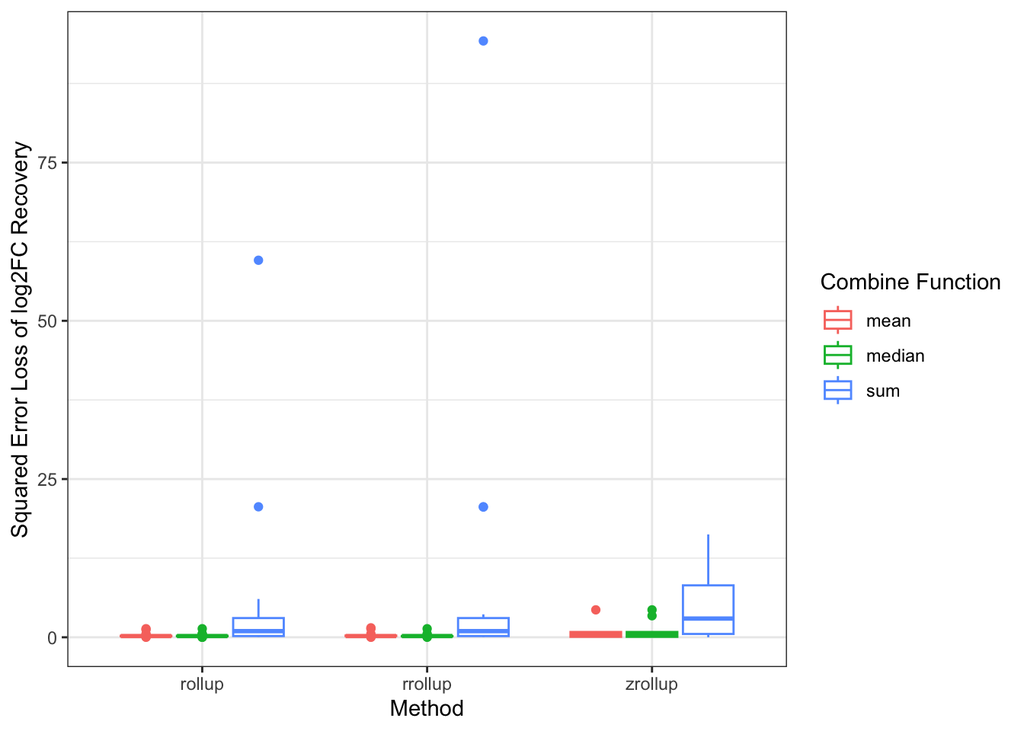

```r
ggdat = out_dat %>% mutate(SEL = (Fold_change_1_vs_2 - true_fold_change)^2)
ggplot(ggdat, aes(x = Method, y = SEL, color = Combine_Function)) +
  geom_boxplot() +
  ylab("Squared Error Loss of log2FC Recovery") +
  labs(color = 'Combine Function') +
  theme_bw()
```

# Expanded Toy Example

Same setup as above, but repeated over 100 simulated datasets.

Set simulation values:

```r
set.seed(seed)
sequence_abundances = c(1000, 1000)

ptm_site_mapping = get_ptm_site_mapping(sequence, amino_acid)
site_sd = 0.1
site_coefs = rnorm(length(unique(ptm_site_mapping$site)), sd = site_sd)

n_per_group = 10
subject_effect_sd = 0.1
subject_coefs = rnorm(n_per_group * 2, sd = subject_effect_sd)
```

Simulation:

```r
n_replicates = 100
set.seed(seed)

out_dat = c()
for(rr in seq_len(n_replicates)){
  out = generate_ptm_samples_for_sequence(ptm_site_mapping,
                                          sequence_abundances,
                                          subject_coefs,
                                          site_coefs,
                                          group_ids = rep(c(1, 2), each = n_per_group))

  ground_truth = data.frame(site = rownames(out$ground_truth),
                            G1 = out$ground_truth[,1],
                            G2 = out$ground_truth[,2]) %>%
    mutate(true_fold_change = log2(G1 / G2)) %>%
    select(site, true_fold_change)

  f_data_full = data.frame(sample = out$e_data %>% select(-peptide) %>% names,
                           group = rep(c(1, 2), each = n_per_group))

  pepdat = as.pepData(e_data = out$e_data,
                    f_data = f_data_full,
                    e_meta = out$e_meta %>% select(-group, -true_peptide_count) %>% distinct(),
                    edata_cname = "peptide",
                    fdata_cname = "sample",
                    emeta_cname = "site")

  pepdat = pmartR::edata_transform(pepdat, "log2")
  pepdat = pmartR::normalize_global(pepdat, subset_fn = 'all', norm_fn = "median", apply_norm = T, backtransform = F)
  pepdat = pmartR::applyFilt(pmartR::molecule_filter(pepdat), pepdat, min_num = 2)
  pepdat = pmartR::group_designation(pepdat, main_effects = 'group')

  methods = c('rollup', 'rrollup', 'zrollup')
  combine_fns = c("mean", "median", "sum")
  combinations = expand.grid(method = methods, combine_fn = combine_fns)
  for(i in seq_len(nrow(combinations))){
    method = combinations$method[i]
    combine_fn = combinations$combine_fn[i]
    single_pep = method == "zrollup"

    sitedat = protein_quant2(pepdat, method, combine_fn = combine_fn, single_pep = single_pep)
    tmp_res = imd_anova(sitedat, test_method = 'anova')
    res = data.frame(tmp_res %>%
                       select(site, starts_with("Fold_change")) %>%
                       left_join(., ground_truth, by = 'site'),
                     Method = method,
                     Combine_Function = combine_fn,
                     replicate = rr)

    out_dat = rbind(out_dat, res)
  }
}
out_dat = as_tibble(out_dat)
```

Performance for each method compared to ground truth:

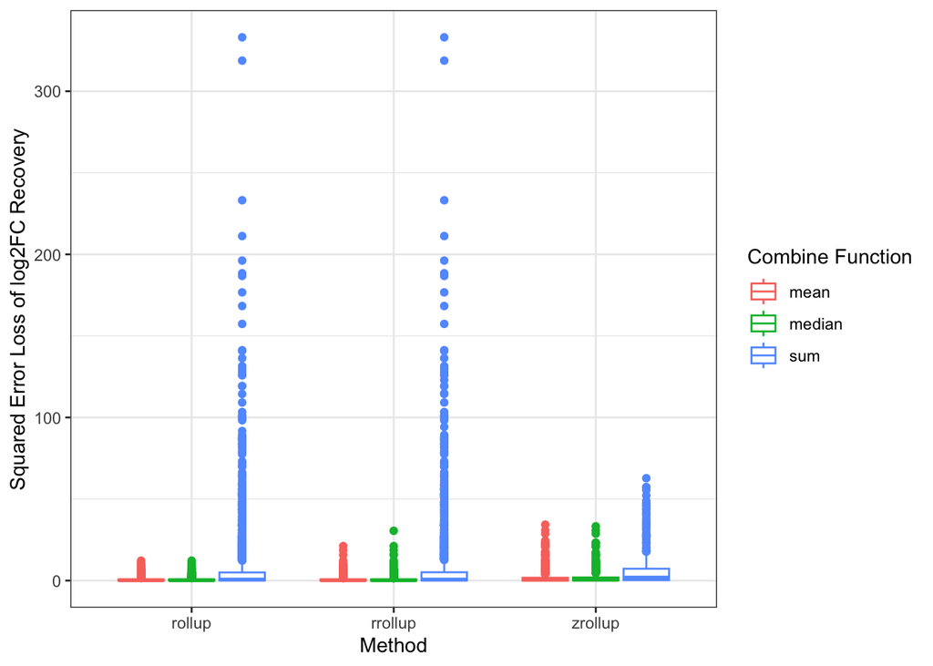

```r
ggdat = out_dat %>% mutate(SEL = (Fold_change_1_vs_2 - true_fold_change)^2)
ggplot(ggdat, aes(x = Method, y = SEL, color = Combine_Function)) +
  geom_boxplot() +
  ylab("Squared Error Loss of log2FC Recovery") +
  labs(color = 'Combine Function') +
  theme_bw()
```